# Mini-Projet : Network Reconstruction

```
                         Lilia HARIRECHE _ Antoine RODRIGUEZ - M2 MLDS FA
```

Les cancers du sein sont classés selon les sous-types d’expression génique suivants: luminal A, luminal B, Her2-enriched (aussi connu sous le nom ERBB2), et basal-like.

Les sous types Luminal sont associés à l’expression des récepteurs des œstrogènes et de la progestérone et des marqueurs de cellules épithéliales luminales différenciées. (*Sequence analysis of mutations and translocations across breast cancer subtypes (Nature 2012, Banerji et al.)*)

Ces sous-types diffèrent par leur complexité génomique, leurs principales altérations génétiques et le pronostic clinique.

L’objectif de ce projet est d’analyser les mutations géniques des quatre types des cancers du sein à partir du tableau de données **breast_cancer** que l’on va construire à l’aide du jeu de données *Breast Invasive Carcinoma (TCGA, PanCancer Atlas)* disponible sur cBioPortal à l’adresse :

https://www.cbioportal.org/study/summary?id=brca_tcga_pan_can_atlas_2018

Nous utiliserons trois approches : l’approche **hill-climbing** (search & score), **MIIC** et **Aracne**.

# Préparation des données

## Chargement des données

La première étape est de récupérer les tableaux de données dont nous aurons besoin pour construire les graphes désirés.

Nous aurons besoin d’abord besoin des données cliniques des échantillons tumoraux et le sous-type de cancer du sein (LuminalA, LuminalB, HER2, basal-like) :

```r
# Informations patients notamment le sous types de cancer
data_clinical_patient <- read.table('brca_tcga_pan_can_atlas_2018/data_clinical_patient.txt',
                                    header=TRUE, sep= '\t')
# Informations patients sur les échantillons de cellules tumorales
data_clinical_sample <- read.table('brca_tcga_pan_can_atlas_2018/data_clinical_sample.txt',
                                   header=TRUE, sep= '\t')
```

Nous souhaitons aussi les informations de l’expression des gènes, cette dernière est bien souvent exprimés par son taux d’ARN messager (ARNm). (http://www.chups.jussieu.fr/polys/biochimie/BGbioch/POLY.Chp.9.25.html)

Plusieurs tableaux sont disponibles et mesure ce taux (https://docs.cbioportal.org/5.1-data-loading/data-loading/file-formats#expression-data), on choisit d’utiliser celui exprimant les Z-scores par rapport à la moyenne des expressions normales des gènes :

```r
# zscores regulation ARNm expliciter le choix
data_RNA_Seq_v2_mRNA_median_all_sample_ref_normal_Zscores <- read.table('brca_tcga_pan_can_atlas_2018/data_RNA_Seq_v2_mRNA_median_all_sample_ref_normal_Zscores.txt',header=TRUE, sep= '\t')
```

En effet, une valeur positive (resp. négative) exprimera une sur-expression (resp. sous_expression).

Le tableau des mutations suivant contient l’information de chacune des mutations identifié sur chaque échantillon tumoral :

```r
# gene mutations compte
data_mutations_extended <- read.table('brca_tcga_pan_can_atlas_2018/data_mutations_extended.txt',header=TRUE, sep= '\t')
```

Ce tableau nous permettra d’identifier les gènes qui subissent le plus de mutations.

## Pré-traitement et création de notre tableau principal

Tout d’abord retirons le superflu et ne gardons que : - `SAMPLE_ID` : les identifiants des échantillons tumoraux - `PATIENT_ID` et `SUBTYPE` de `data_clinical_sample` pour pouvoir reconstruire des graphes suivant le sous types de cancers - les niveaux d’expressions des gènes des 20 gènes mutants les plus présents dans chaque échantillons

```r
data_clinical_sample <- data_clinical_sample[,1:2]
patients <- data_clinical_patient[c('PATIENT_ID',"SUBTYPE")]
mRNA <- data_RNA_Seq_v2_mRNA_median_all_sample_ref_normal_Zscores[-2]
```

```r
mutations <- data_mutations_extended[c("Hugo_Symbol","Tumor_Sample_Barcode","t_ref_count","t_alt_count")]
```

```r
patients[patients['SUBTYPE'] == '','SUBTYPE'] = NA
# sum(is.na(mutations))  ## le tableau ne contient pas de NA
mRNA <- mRNA[mRNA['Hugo_Symbol'] != '',]  # supprime les lignes de gènes sans noms
```

Cherchons maintenant à déterminer les 20 gènes mutants les plus représentés :

```r
genes = tapply(mutations$Tumor_Sample_Barcode,
               mutations$Hugo_Symbol,
               FUN = function(x) length(unique(x)))
length(genes) # nombre de gènes uniques
```

```
## [1] 16664
```

```r
library(viridis) # palette de couleurs
```

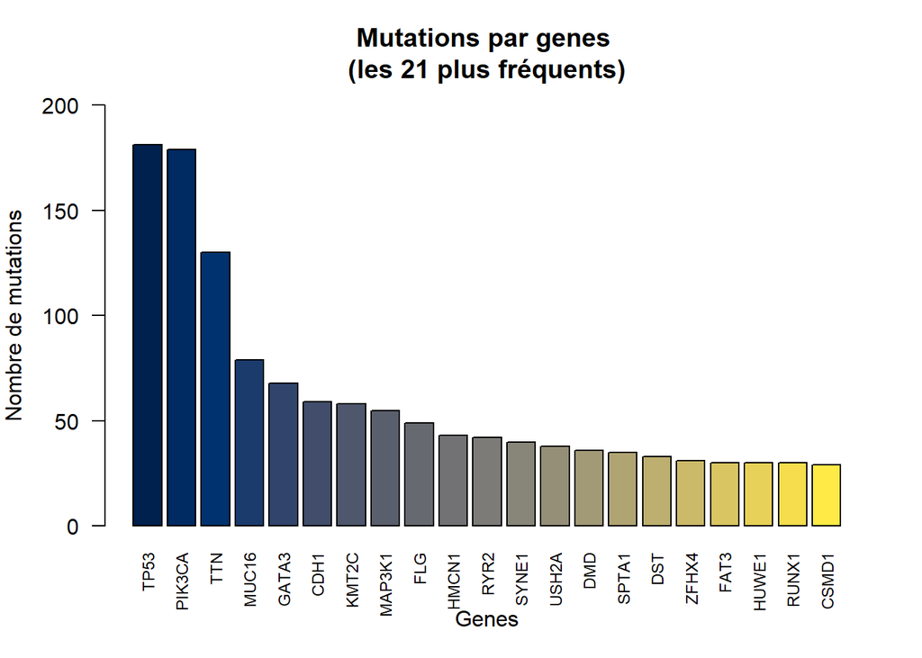

```r
par(mar=c(5,4,4,2))
barplot(sort(genes,decreasing=TRUE)[1:21],
        col=viridis(21,option ="E"),
        xlab="Genes",
        ylab="Nombre de mutations",
        main="Mutations par genes \n (les 21 plus fréquents) ",
        ylim=c(0,200),
        las=2,
        cex.names=0.75
        )
```

```r
genes_sorted = sort(genes,decreasing=TRUE)[1:21]
genes_sorted #print
```

```
##   TP53 PIK3CA    TTN  MUC16  GATA3   CDH1  KMT2C MAP3K1    FLG  HMCN1   RYR2
##    181    179    130     79     68     59     58     55     49     43     42
##  SYNE1  USH2A    DMD  SPTA1    DST  ZFHX4   FAT3  HUWE1  RUNX1  CSMD1
##     40     38     36     35     33     31     30     30     30     29
```

Les gènes tels que TP53, PIK3CA, GATA3, MAP3K1 et RUNX1 ont été précédemment identifiés comme très fortement impliqués dans les cancers du sein. (*Comprehensive molecular portraits of human breast tumours (Nature 2012, Koboldt et al.)*)

On filtre donc les deux tableaux selon ces gènes :

```r
genes = names(genes_sorted) # 21
mRNA_filtered <- mRNA[mRNA$Hugo_Symbol %in% genes,]
mutations_filtered <- mutations[mutations$Hugo_Symbol %in% genes,]
```

```r
library(stringr)  # for strings operations
```

```r
col = str_replace_all(colnames(mRNA_filtered), "[.]", "-") # renommer les SAMPLE_ID
colnames(mRNA_filtered) <- col
```

On commence donc à construire notre tableau principal contenant les 20 gènes, `SAMPLE_ID` et le sous type de cancer correspondant (tout cela à l’aide de requêtes merge entre les trois tableau précédents)

```r
tab <- data.frame(t(mRNA_filtered))
colnames(tab) <- tab['Hugo_Symbol',]
tab <- tab[-1,]
```

```r
sample_subtype <- merge(data_clinical_sample,patients,by.y='PATIENT_ID')
```

```r
tab <- cbind('SAMPLE_ID'=rownames(tab),tab)
rownames(tab) <- NULL
tab <- merge(sample_subtype[,c('SAMPLE_ID','SUBTYPE')],tab,by.y='SAMPLE_ID')
```

```r
write.csv(tab,"breast.csv", row.names=FALSE)  # enregistrement pour exécution du notebook plus rapide
```

# Construction des graphes et interprétations

Voici tout d’abord le tableau sur lequel nous allons travailler :

```r
breast_cancer <- read.csv("breast.csv")
head(breast_cancer)
```

|  | SAMPLE_ID | SUBTYPE | CDH1 | CSMD1 | DMD | DST | FAT3 | FLG | GATA3 | HMCN1 | HUWE1 | MAP3K1 | MUC16 | PIK3CA | RUNX1 | RYR2 | SPTA1 | SYNE1 | TP53 | TTN | USH2A | ZFHX4 |
| --- | --- | --- | --- | --- | --- | --- | --- | --- | --- | --- | --- | --- | --- | --- | --- | --- | --- | --- | --- | --- | --- | --- |
| 1 | TCGA-3C-AAAU-01 | BRCA_LumA | 0.7441 | -1.6562 | -8.2408 | -2.6293 | -2.7386 | -3.8104 | 1.6484 | -3.4910 | 1.5586 | 1.1157 | -3.1070 | -1.3910 | 1.3250 | -1.1725 | -1.5278 | -3.1300 | -0.0905 | -1.1050 | -0.4910 | -1.8013 |
| 2 | TCGA-3C-AALI-01 | BRCA_Her2 | 0.6214 | -1.8906 | -6.6421 | -2.8095 | -2.3269 | -2.1694 | 1.0525 | -1.1341 | 1.4945 | -0.5176 | -1.3878 | -2.3955 | -0.3930 | -1.2537 | -0.2852 | -3.8396 | -3.0785 | -0.7511 | -1.3315 | -1.9924 |
| 3 | TCGA-3C-AALJ-01 | BRCA_LumB | 0.4001 | -2.9480 | -6.5725 | -4.0137 | -2.6019 | -1.4665 | 1.3439 | -1.0623 | -1.8193 | -0.6732 | -3.2975 | -3.3548 | 1.0012 | -1.6815 | -1.3973 | -3.3502 | -0.2690 | -0.6282 | 0.3822 | -0.9036 |
| 4 | TCGA-3C-AALK-01 | BRCA_LumA | 0.4507 | 0.2366 | -5.5904 | -2.8701 | -0.6130 | -0.9510 | 1.2012 | 0.4951 | -0.7985 | 0.9809 | -1.8653 | -2.3648 | 1.2945 | -0.3201 | -1.0405 | -2.6255 | -0.0327 | -0.6912 | -0.5200 | -0.1483 |
| 5 | TCGA-4H-AAAK-01 | BRCA_LumA | -0.8660 | 1.4151 | -5.7241 | -3.5243 | 0.3034 | -1.4629 | 1.6312 | 0.9137 | -1.0123 | -0.0621 | -2.2848 | -1.8075 | 1.0210 | -0.0473 | -0.4949 | -1.9593 | 0.0800 | -0.2811 | -0.8706 | 0.1054 |
| 6 | TCGA-5L-AAT0-01 | BRCA_LumA | 0.1545 | -0.0218 | -5.5977 | -3.2188 | 0.2331 | -0.4669 | 1.7765 | -0.1193 | -1.3732 | 1.1984 | -1.2572 | -2.1954 | 0.6155 | 0.0501 | -0.9987 | -1.8724 | 0.0610 | -0.7664 | -0.1387 | -1.0741 |

Nous chercherons à établir les graphes pour chacuns des sous-types :

- `BRCA_LumA` : luminal A
- `BRCA_LumB` : luminal B
- `BRCA_Her2` : HER2
- `BRCA_Basal` : basal-like

en plus d’un graphe établit sur tout les échantillons.

```r
distrib_subtypes = tapply(breast_cancer$SAMPLE_ID,
                          breast_cancer$SUBTYPE,
                          FUN = function(x) length(unique(x)))
```

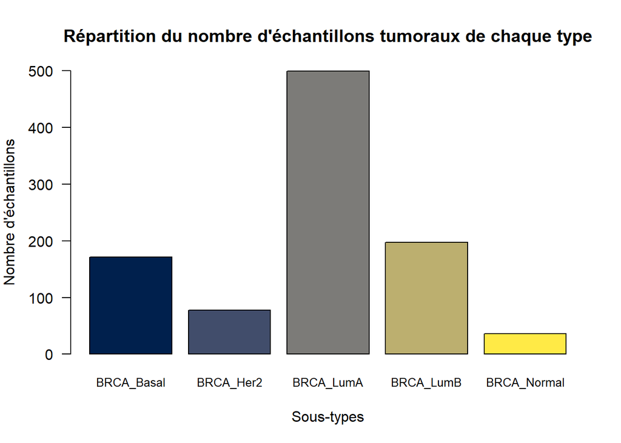

```r
par(mar=c(5,4,4,2))
barplot(distrib_subtypes,
        col=viridis(5, option ="E"),
        xlab="Sous-types",
        ylab="Nombre d'échantillons",
        main="Répartition du nombre d'échantillons tumoraux de chaque type",
        ylim=c(0,500),
        las=1,
        cex.names=0.8
        )
```

Construisons les graphes selon différentes approches et selon les différents sous-types de cancers du sein.

On établit d’abord quelques paramètres pour l’affichage de nos graphes :

```r
# palette de couleur pour 20 sommets de graphes
df_col <- data.frame(genes_sorted)
df_col <- cbind('GENE_ID'=rownames(df_col),df_col)
df_col <- df_col[df_col['GENE_ID']!='KMT2C',]
df_col$ver_col <- viridis(20,option ="E")
```

```r
# chargement des librairies
library(bnlearn)
library(igraph)
```

## Search & Score (Hill Climbing)

On souhaite représenter les graphes pour chacuns des sous types, nous le comparerons directement avec le graphe construit à partir de toute les données.

```r
net_hc <- bnlearn::hc(breast_cancer[,-c(1,2)])
mat_hc <- bnlearn::amat(net_hc)
graph_hc <- graph_from_adjacency_matrix(mat_hc,
                                        diag = FALSE,
                                        weight = TRUE,
                                        mode = "directed")
E(graph_hc)$type = 1 # type 1 : tout le dataset

hc_net_construct <- function(subtype){
  # creation du graphe du sous-type subtype
  net_hc <- bnlearn::hc(subset(breast_cancer,
                             SUBTYPE==subtype)[,-c(1,2)])
  mat_hc <- bnlearn::amat(net_hc)
  graph <- graph_from_adjacency_matrix(mat_hc,
                                       diag = FALSE,
                                       weight = TRUE,
                                       mode = "directed")
  E(graph)$type = 2 # type 2 : sous-type
  g = graph.union(graph_hc, graph, byname="auto")
  E(g)$type_1[is.na(E(g)$type_1)] <- 0
  E(g)$type_2[is.na(E(g)$type_2)] <- 0
  E(g)$type <- E(g)$type_1 + E(g)$type_2
  # 1 = type 1, 2 = type 2, 3 = type 1 et 2
  return(g)
}

edg_col <- function(g){
  # code couleur pour les edges
  # black : tout les types, red : sous-types, purple : apparition dans les deux
  dic=c(1,2,3)
  names(dic) = c('#DADADA','red','#F45B5B')
  return(names(dic[E(g)$type]))
}

g1 = hc_net_construct('BRCA_LumA')
g2 = hc_net_construct('BRCA_LumB')
g3 = hc_net_construct('BRCA_Her2')
g4 = hc_net_construct('BRCA_Basal')
```

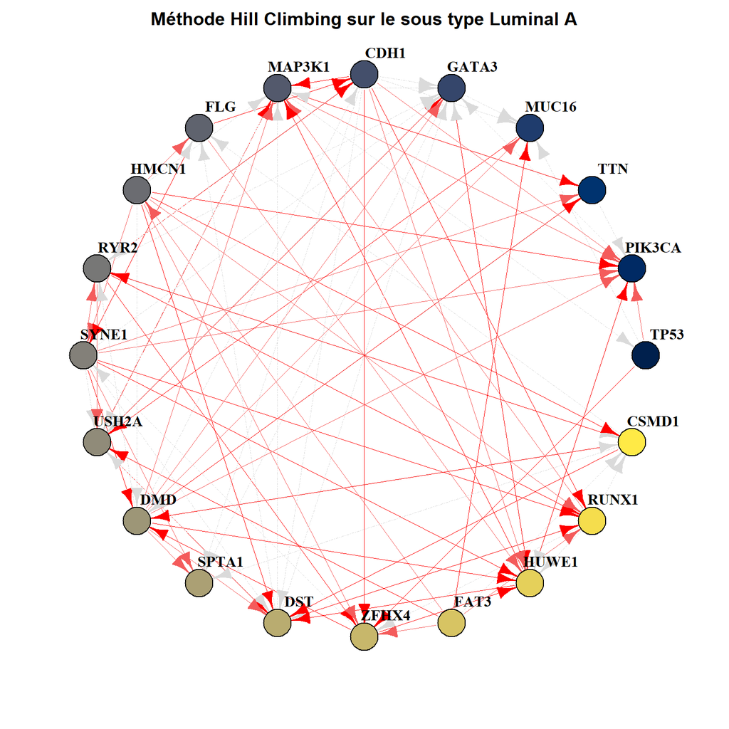

```r
plot_graph <- function(g, titre){
  # affichage de graphes construits avec les méthodes
  # hill climbing , aracne et miic
  layout <- layout_in_circle(g, order=names(genes_sorted)[-7])
  par(mar=c(2,2,2,2), oma=c(1,0,0,0)) #marges

  plot(g,
       layout = layout,

       edge.width = 0.1,
       edge.arrow.size = 1,
       edge.color = edg_col(g),
       edge.lty = ifelse(E(g)$type==1, 4, 1),

       vertex.size = 10,
       vertex.label.dist = 1.5,
       vertex.label.font = 2,
       vertex.label.cex = 1,
       vertex.label.color = "black",
       vertex.color = df_col[V(g)$name, 'ver_col'],
       vertex.frame.color = "black",

       main = titre)
}

plot_graph(g1, 'Méthode Hill Climbing sur le sous type Luminal A')
```

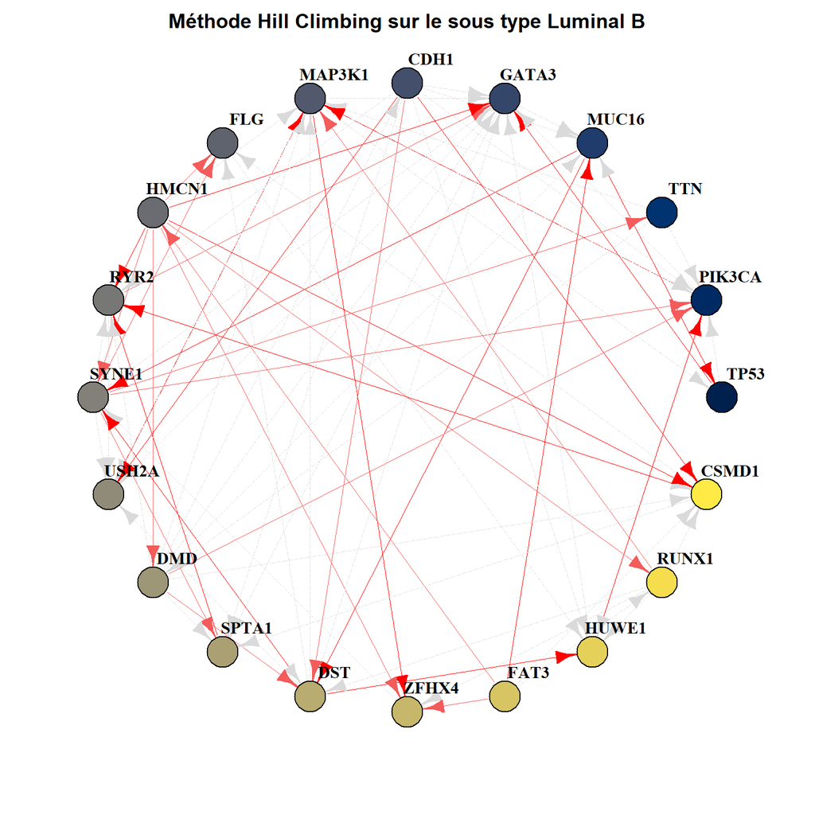

```r
plot_graph(g2, 'Méthode Hill Climbing sur le sous type Luminal B')
```

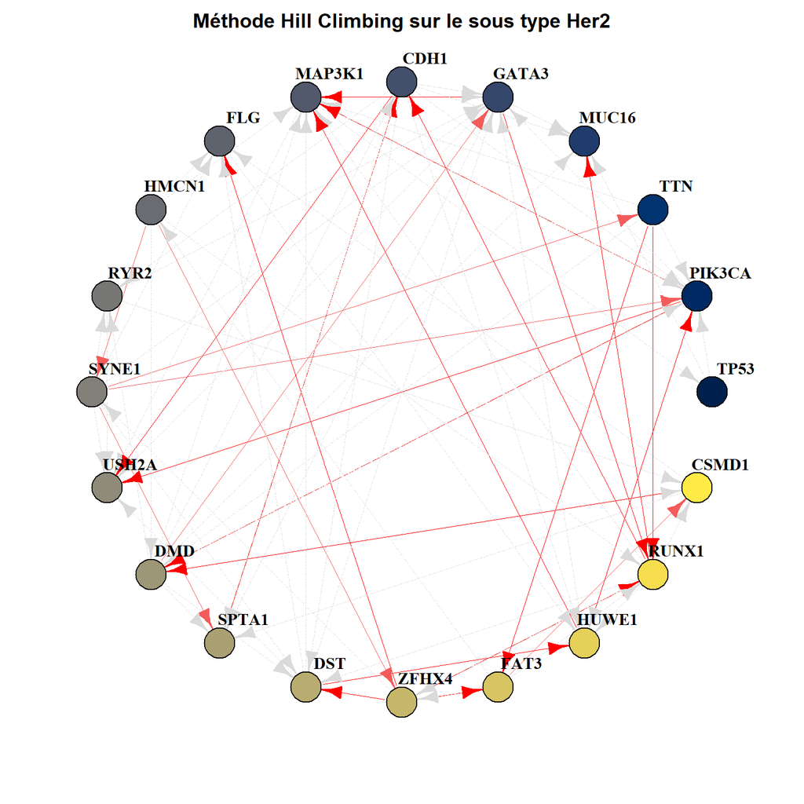

```r
plot_graph(g3, 'Méthode Hill Climbing sur le sous type Her2')
```

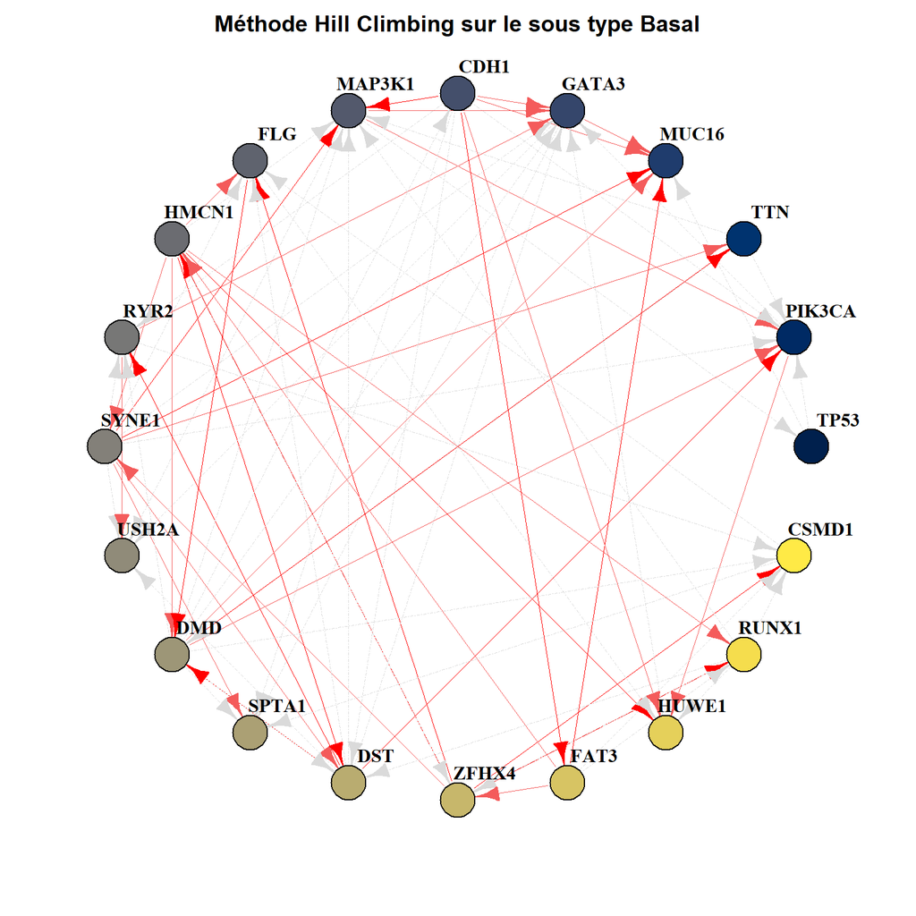

```r
plot_graph(g4, 'Méthode Hill Climbing sur le sous type Basal')
```

Quelques précisions à propos des graphes représentés :

- La couleur des sommets représente le nombre de mutations par gènes (clair : moins de mutations, foncé : plus de mutations)
- Les arêtes en gris clair représentent les arêtes du graphe (*) construit à partir de tout `breast_cancer` indépendamment du sous type
- Les arêtes rouges présentent la construction de graphe résteinte à un sous type de cancer

**N.B. :** Les arêtes rouges légèrement plus claires sont celles partagées avec ce graphe (*)

La méthode search & score (ici hill climbing) a tendance à “faire plus de lien” entre les sommets. Il est ici compliqué d’identifier des chemins de mutations entre les gènes.

On remarque néanmoins que le gène TP53 semble moins régulé par les autres gènes.

## Méthode ARACNE

On peux construire les graphes comme la méthode précédente :

```r
net_ar <- bnlearn::aracne(breast_cancer[,-c(1,2)])
mat_ar <- bnlearn::amat(net_ar)
graph_ar <- graph_from_adjacency_matrix(mat_ar,
                                        diag = FALSE,
                                        weight = TRUE,
                                        mode = "directed")
E(graph_ar)$type = 1 # type 1 : tout le dataset

ar_net_construct <- function(subtype){
  # creation du graphe du sous-type subtype
  net_ar <- bnlearn::aracne(subset(breast_cancer,
                             SUBTYPE==subtype)[,-c(1,2)])
  mat_ar <- bnlearn::amat(net_ar)
  graph <- graph_from_adjacency_matrix(mat_ar,
                                       diag = FALSE,
                                       weight = TRUE,
                                       mode = "directed")
  E(graph)$type = 2 # type 2 : sous-type
  g = graph.union(graph_ar, graph, byname="auto")
  E(g)$type_1[is.na(E(g)$type_1)] <- 0
  E(g)$type_2[is.na(E(g)$type_2)] <- 0
  E(g)$type <- E(g)$type_1 + E(g)$type_2
  # 1 = type 1, 2 = type 2, 3 = type 1 et 2
  return(g)
}

edg_col <- function(g){
  # code couleur pour les edges
  # black : tout les types, red : sous-types, purple : apparition dans les deux
  dic=c(1,2,3)
  names(dic) = c('#DADADA','red','#F45B5B')
  return(names(dic[E(g)$type]))
}

g1 = ar_net_construct('BRCA_LumA')
g2 = ar_net_construct('BRCA_LumB')
g3 = ar_net_construct('BRCA_Her2')
g4 = ar_net_construct('BRCA_Basal')
```

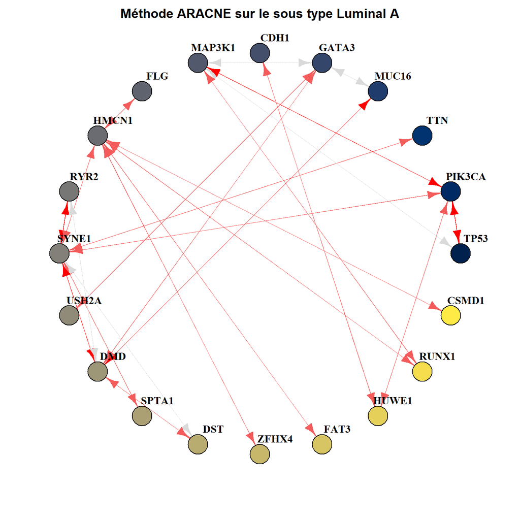

```r
plot_graph(g1, 'Méthode ARACNE sur le sous type Luminal A')
```

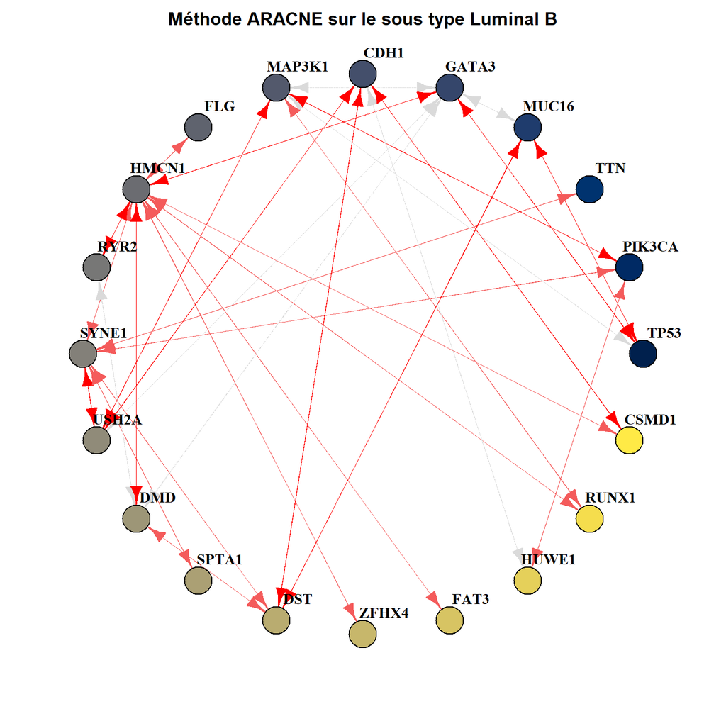

```r
plot_graph(g2, 'Méthode ARACNE sur le sous type Luminal B')
```

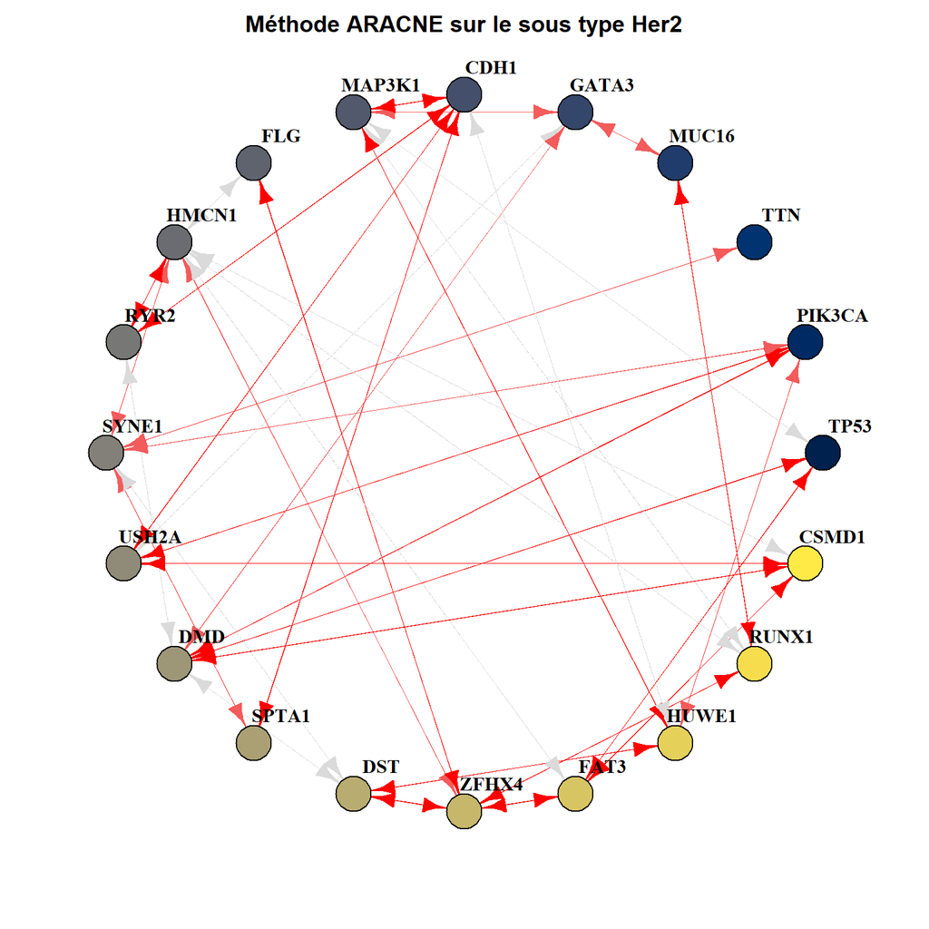

```r
plot_graph(g3, 'Méthode ARACNE sur le sous type Her2')
```

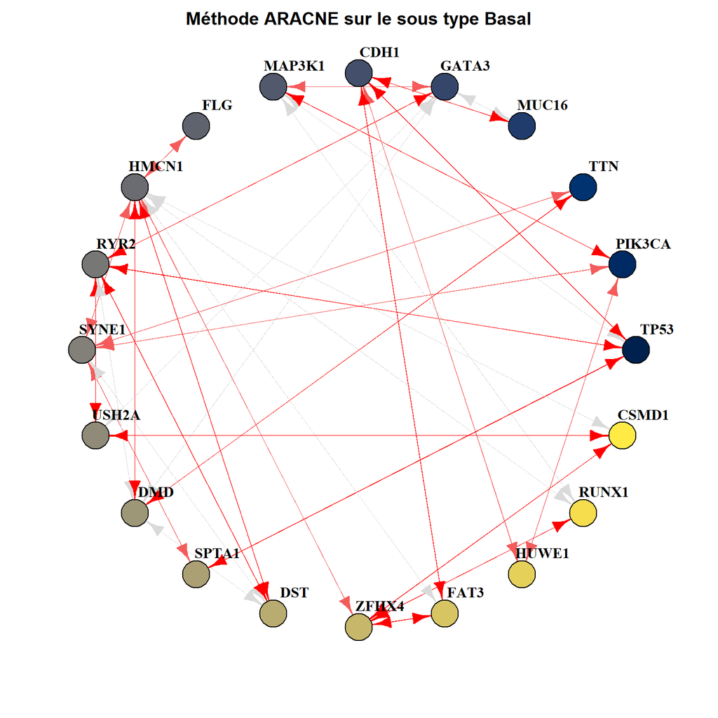

```r
plot_graph(g4, 'Méthode ARACNE sur le sous type Basal')
```

Dans les cancers de type Luminal HMCN1 semble jouer un rôle important dans la régulation de nombreux gènes notamment dans LUminal B.

Dans une moindre mesure le gène SYNE1 aussi.

## Methode MIIC

```r
miic.res <- miic(input_data = breast_cancer[,-c(1,2)],
                 latent = "yes",
                 n_shuffles = 10,
                 conf_threshold = 0.009)
graph_miic <- miic::miic.export(miic.res, method = "igraph")

E(graph_miic)$type = int(1) # type 1 : tout le dataset

miic_net_construct <- function(subtype){
  # creation du graphe du sous-type subtype
  miic.res <- miic(subset(breast_cancer,
                          SUBTYPE==subtype)[,-c(1,2)],
                   latent = "yes",
                   n_shuffles = 10,
                   conf_threshold = 0.009)
  graph <- miic::miic.export(miic.res, method = "igraph")
  E(graph)$type = 2 # type 2 : sous-type
  g = graph.union(graph_miic, graph, byname="auto")
  E(g)$type_1[is.na(E(g)$type_1)] <- 0
  E(g)$type_2[is.na(E(g)$type_2)] <- 0
  E(g)$type <- strtoi(E(g)$type_1) + strtoi(E(g)$type_2)
  # 1 = type 1, 2 = type 2, 3 = type 1 et 2
  return(g)
}

g1 = miic_net_construct('BRCA_LumA')
g2 = miic_net_construct('BRCA_LumB')
g3 = miic_net_construct('BRCA_Her2')
g4 = miic_net_construct('BRCA_Basal')
```

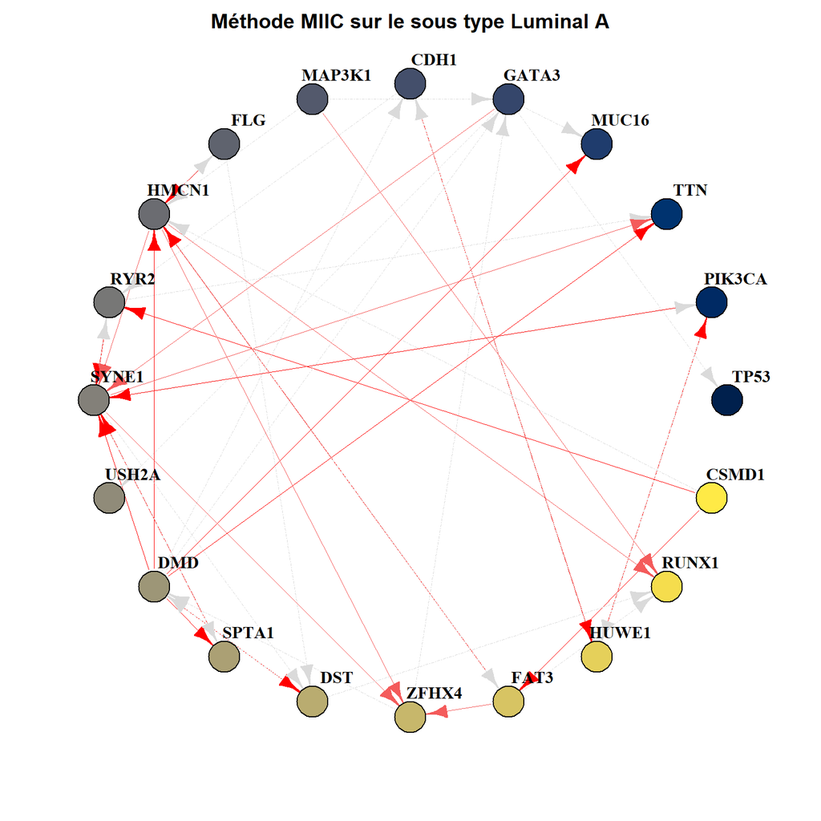

```r
plot_graph(g1, 'Méthode MIIC sur le sous type Luminal A')
```

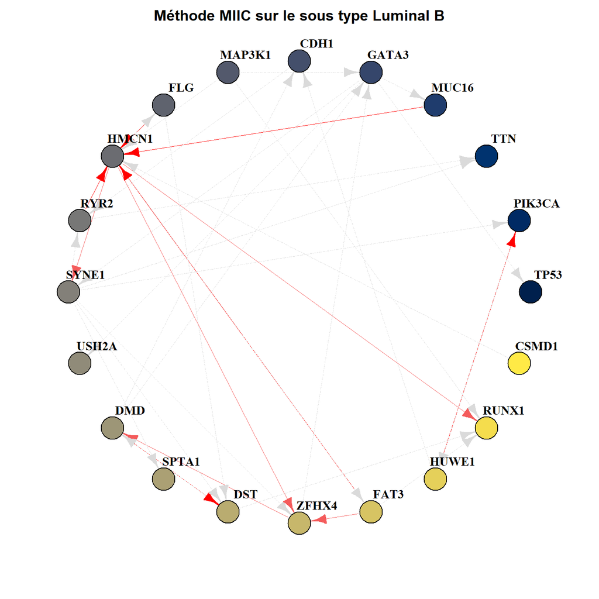

```r
plot_graph(g2, 'Méthode MIIC sur le sous type Luminal B')
```

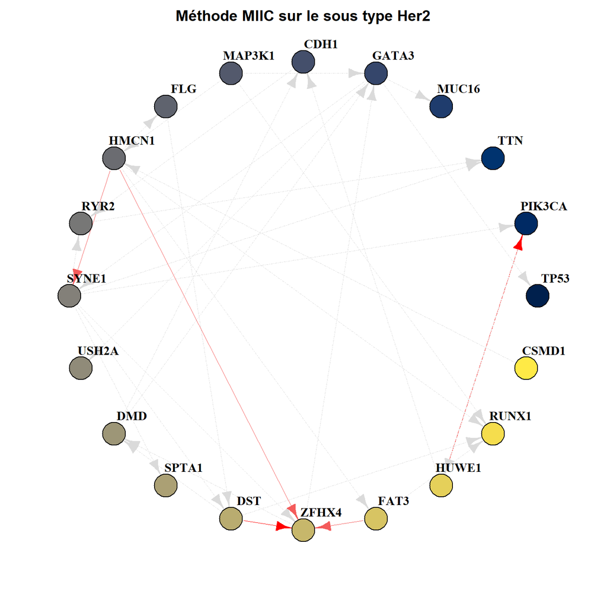

```r
plot_graph(g3, 'Méthode MIIC sur le sous type Her2')
```

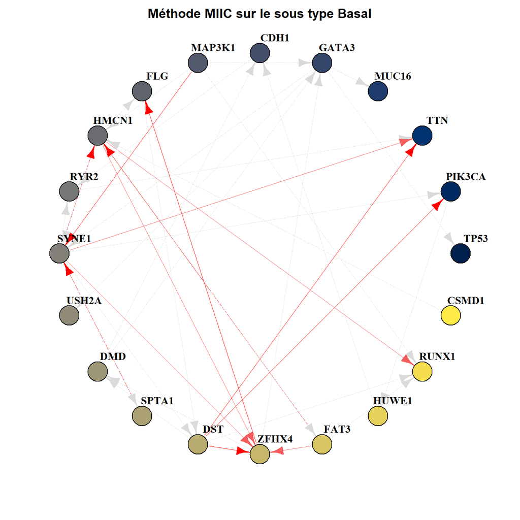

```r
plot_graph(g4, 'Méthode MIIC sur le sous type Basal')
```

Les commentaires établit à propos de HMCN1 et SYNE1 dans la méthode précédente cse confirme ici.

On remarque aussi une importance du gène ZFHX4 dans les cancers de sous-types HER2 et basal-like.

## Discussion

Les articles Kobolt et Benarji ne font pas état des gènes HMCN1, SYNE1, or on remarque ici que leur régulation pourrait jouer un rôle dans les cancers de type Luminal.

De plus, retrospectivement, la mise en avant du gène ZFHX4 dans la méthode MIIC peut aussi être aperçu via la méthode ARACNE.

On remarque que le niveau de relation entre le gène **TP53** et les autres gènes est souvent plus faible, dans les articles il est indiqué que celui-ci est fortement cimpliqué dans les cancers du sein, *“on pourrait imaginer qu’il se suffit à lui même et n’entre pas dans des chemins de mutations.”*

Ce genre d’étude nous montre d’un point de vue biologique comment les gènes sont impliqués dans la formation des cellules cancéreuses et leurs niveaux d’expression selon le type de cancer.

Ces réseaux cherchent à représenter des chemins de mutations entre les gènes et pourraient nous aider à déterminer d’éventuelles régulations entre ceux-ci. Supprimer ces liens pourrait éventuellement permettre de réguler la formation de cellules cancéreuses et donc le taux de cancer de sein.